# Prosper Loan Dataset Investigation

## Analysis done by: Zahra Al-Hourani

## Investigation Overview

> The main interest is to figure out What factors affect a borrower Rate, borrower APR, Loan Status.

## Dataset Overview

> This dataset is financial and related to the Loan, Borrowers, Lenders, Interest rates, etc. Prosper or Prosper Marketplace Inc. is a San Francisco, California-based company specializing in loans at low-interest rates to borrowers. In this dataset, we are using the data from Prosper to analyze it and trying to find the pattern in the Prosper data.

> The dataset is comprised of 81 variables and contains 113937 entries.

## Correlation Map

##### Sometimes a negative correlation is logical and meaningful, I noticed from the previous chart some negative values that are meaningful. Like:

- 'BorrowerAPR and ProsperScore' have a negative correlation,The lower ProsperScor, leads to an increase in risks, and therefore interest rates will increase.
- 'LenderYield and ProsperScore' have a negative correlation, The higher ProsperScor, the interest rate will decrease, and therefore the return on the lender will decrease.

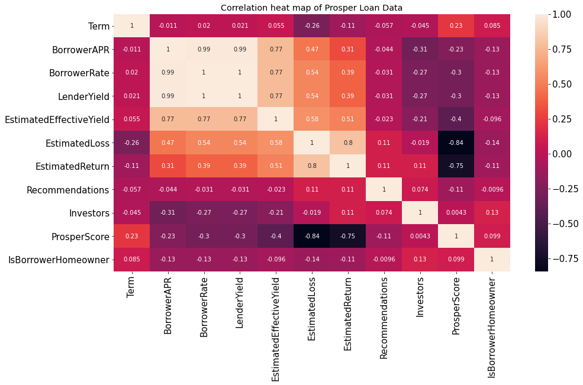

- The box plot shows that there is an indications that 'Prosperscore' is a good factor to determine the 'BorrowersAPR'. the lower ProsperScor, This leads to an increase in risks, and therefore interest rates will increase.

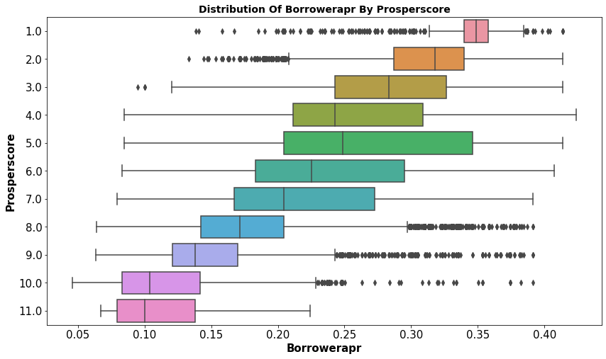

- 'LenderYield and ProsperScore' have a negative correlation, The higher ProsperScor, the interest rate will decrease, and therefore the return on the lender will decrease.

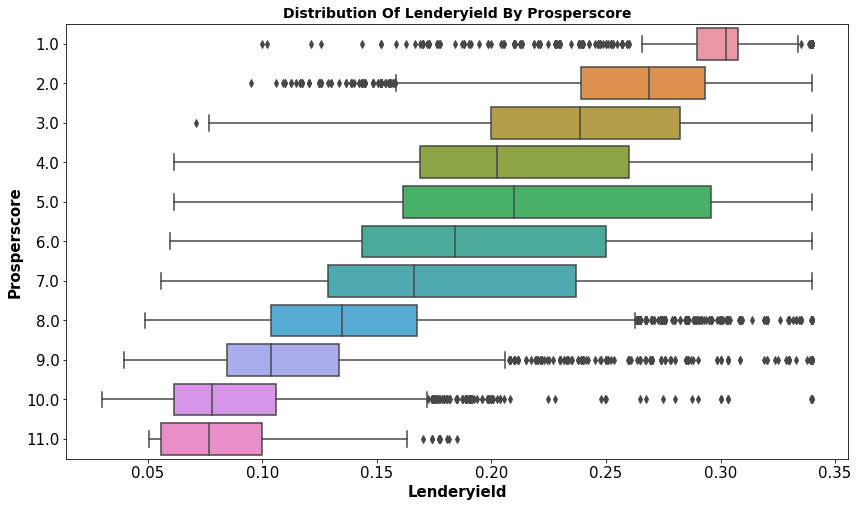

- The scatter chart shows a strong relationship between 'BorrowerRate' and 'LenderYield' which means The higher Rate the higher the lenderYield 'the interest rate on the loan'.
- High 'EstimatedReturn' repeated with the positive correlation between the 'LenderYield' and 'BorrowerRate'.

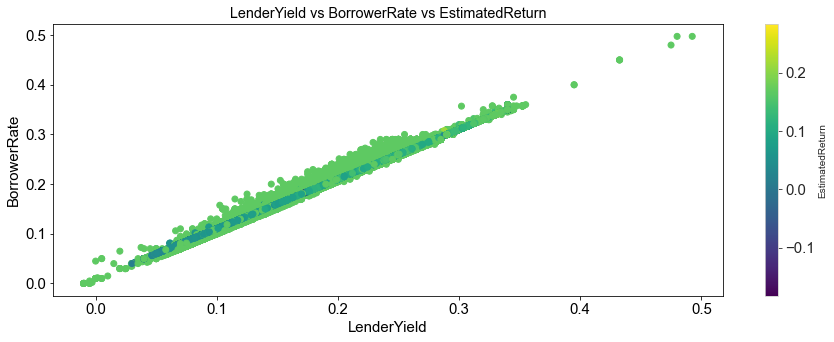

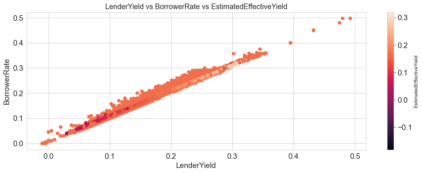

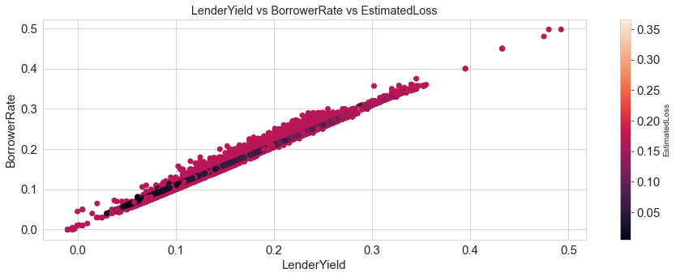

- The scatter plot shows a strong relationship between 'BorrowerAPR' and 'LenderYield' which means The higher the Annual Percentage Rate the higher the lenderYield 'the interest rate on the loan'.
- Also, the chart shows that the loans with lower 'BorrowerAPR' and 'LenderYield' have higher ProsperScore and vice versa

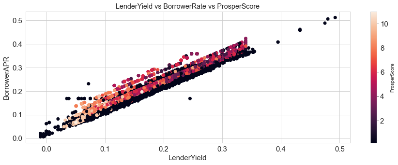

- The plot shows that it seems like home owners have a lower rate than the non home owners.

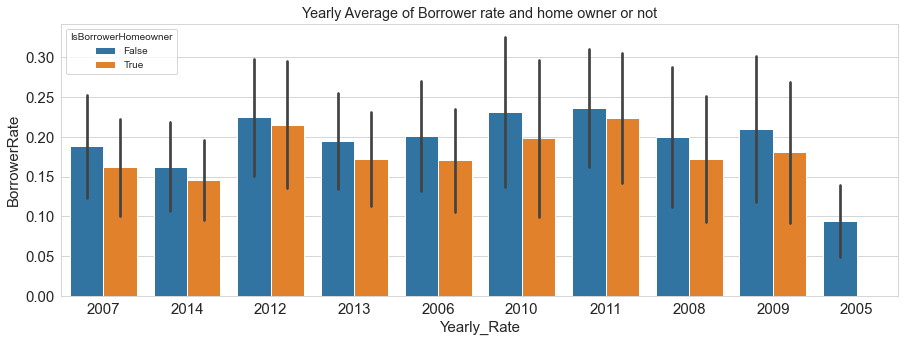

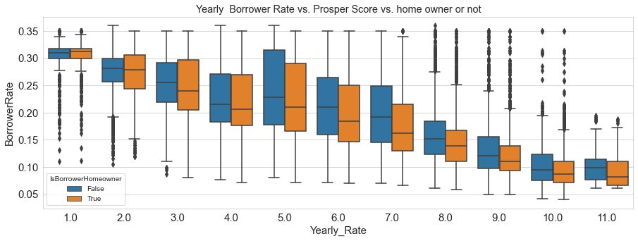